# P&S-2022: Lab assignment 2

Yaroslav Korch, Muzychuk Teodor, Kharabara Yurii

## General comments and instructions

- Complete solution will give you $\bf 4$ points (out of 100 total). Submission deadline is **23:59 of 06 November 2022**
- The report must be prepared as an *R notebook*; you must submit to **cms** both the source *R notebook* **and** the generated html file
- At the beginning of the notebook, provide a work-breakdown structure estimating efforts of each team member
- For each task, include
  - problem formulation and discussion (what is a reasonable answer to discuss);
  - the corresponding $\mathbf{R}$ code with comments (usually it is just a couple of lines long);
  - the statistics obtained (like sample mean or anything else you use to complete the task) as well as histograms etc to illustrate your findings;
  - justification of your solution (e.g. refer to the corresponding theorems from probability theory);
  - conclusions (e.g. how reliable your answer is, does it agree with common sense expectations etc)
- The **team id number** referred to in tasks is the **two-digit** ordinal number of your team on the list. Include the line **set.seed(team id number)** at the beginning of your code to make your calculations reproducible. Also observe that the answers **do** depend on this number!
- Take into account that not complying with these instructions may result in point deduction regardless of whether or not your implementation is correct.

### Task 1

#### In this task, we discuss the $[7,4]$ Hamming code and investigate its reliability. That coding system can correct single errors in the transmission of $4$-bit messages and proceeds as follows:

- given a message $\mathbf{m} = (a_1 a_2 a_3 a_4)$, we first encode it to a $7$-bit *codeword* $\mathbf{c} = \mathbf{m}G = (x_1 x_2 x_3 x_4 x_5 x_6 x_7)$, where $G$ is a $4\times 7$ *generator* matrix
- the codeword $\mathbf{c}$ is transmitted, and $\mathbf{r}$ is the received message
- $\mathbf{r}$ is checked for errors by calculating the *syndrome vector* $\mathbf{z} := \mathbf{r} H$, for a $7 \times 3$ *parity-check* matrix $H$
- if a single error has occurred in $\mathbf{r}$, then the binary $\mathbf{z} = (z_1 z_2 z_3)$ identifies the wrong bit no. $z_1 + 2 z_2 + 4z_3$; thus $(0 0 0)$ shows there was no error (or more than one), while $(1 1 0 )$ means the third bit (or more than one) got corrupted
- if the error was identified, then we flip the corresponding bit in $\mathbf{r}$ to get the corrected $\mathbf{r}^* = (r_1 r_2 r_3 r_4 r_5 r_6 r_7)$;
- the decoded message is then $\mathbf{m}^*:= (r_3r_5r_6r_7)$.

#### The **generator** matrix $G$ and the **parity-check** matrix $H$ are given by

$$G :=
\begin{pmatrix}
1 & 1 & 1 & 0 & 0 & 0 & 0 \\
1 & 0 & 0 & 1 & 1 & 0 & 0 \\
0 & 1 & 0 & 1 & 0 & 1 & 0 \\
1 & 1 & 0 & 1 & 0 & 0 & 1 \\
\end{pmatrix},
\qquad
H^\top := \begin{pmatrix}
1 & 0 & 1 & 0 & 1 & 0 & 1 \\
0 & 1 & 1 & 0 & 0 & 1 & 1 \\
0 & 0 & 0 & 1 & 1 & 1 & 1
\end{pmatrix}$$

#### Assume that each bit in the transmission $\mathbf{c} \mapsto \mathbf{r}$ gets corrupted independently of the others with probability $p = \mathtt{id}/100$, where $\mathtt{id}$ is your team number. Your task is the following one.

1. Simulate the encoding-transmission-decoding process $N$ times and find the estimate $\hat p$ of the probability $p^*$ of correct transmission of a single message $\mathbf{m}$. Comment why, for large $N$, $\hat p$ is expected to be close to $p^*$.
2. By estimating the standard deviation of the corresponding indicator of success by the standard error of your sample and using the CLT, predict the interval $(p^*-\varepsilon, p^* + \varepsilon)$, in which the estimate $\hat p$ falls with probability at least $0.95$.
3. What choice of $N$ guarantees that $\varepsilon \le 0.03$?
4. Draw the histogram of the number $k = 0,1,2,3,4$ of errors while transmitting a $4$-digit binary message. Do you think it is one of the known distributions?

#### You can (but do not have to) use the chunks we prepared for you

#### First, we set the **id** of the team and define the probability $p$ and the generator and parity-check matrices $G$ and $H$

```r
# your team id number
                          ###
id <- 9                   ### Change to the correct id!
                          ###
set.seed(id)
p <- id/100
# matrices G and H
G <- matrix(c(1, 1, 1, 0, 0, 0, 0,
        1, 0, 0, 1, 1, 0, 0,
        0, 1, 0, 1, 0, 1, 0,
        1, 1, 0, 1, 0, 0, 1), nrow = 4, byrow = TRUE)
H <- t(matrix(c(1, 0, 1, 0, 1, 0, 1,
        0, 1, 1, 0, 0, 1, 1,
        0, 0, 0, 1, 1, 1, 1), nrow = 3, byrow = TRUE))
# cat("The matrix G is: \n")
#G
#cat("The matrix H is: \n")
#H
#cat("The product GH must be zero: \n")
#(G%*%H) %%2
```

#### Next, generate the messages

```r
# generate N messages

message_generator <- function(N) {
  matrix(sample(c(0,1), 4*N, replace = TRUE), nrow = N)
}
messages <- message_generator(100)
codewords <- (messages %*% G) %% 2
```

#### Generate random errors; do not forget that they occur with probability $p$! Next, generate the received messages

### Task 1.1

```r
simulation <- function(message_number){
  messages <- message_generator(message_number)
  codewords <- (messages %*% G) %% 2
  for (i in 1:length(codewords[,1])){
        for (digit in 1:length(codewords[i,])){
            number_with_prob_p <- sample(c(1, 0), 1, prob = c(p, 1-p), replace = T)
            if (number_with_prob_p == 1){
                if (codewords[i,digit] == 1){
                    codewords[i,digit] <- 0
                } else {
                    codewords[i,digit] <- 1
                }
            }
        }
  }
    decoded <- messages
    for (i in 1:length(codewords[,1])){
        z <- (matrix(c(codewords[i,]), nrow = 1, byrow = TRUE)%*%H)%%2
        num <- z[1,1] + 2*z[1,2] + 4*z[1,3]
        if (num != 0){
            if (codewords[i,num] == 0){
                codewords[i,num] <- 1
            } else {
                codewords[i,num] <- 0
            }
        }
        decoded[i,1] <- codewords[i,3]
        decoded[i,2] <- codewords[i,5]
        decoded[i,3] <- codewords[i,6]
        decoded[i,4] <- codewords[i,7]
    }

    appearances = c(0, 0, 0, 0, 0)
    for (ind in 1:length(messages[,1])) {
      mess <- messages[ind,]
      res <- decoded[ind,]
      counter <- 0
      for (j in 1:4){
        if (mess[j] != res[j]){
          counter = counter + 1
        }
      }
      appearances[counter+1] = appearances[counter+1] + 1
    }

    return(appearances)
}
```

The probability $p*$ is the probability that everything was ok. (That there were no mistakes, or message had no more than one mistake) Thus, $p* = (1-p)^7 + {7\choose 1}(1-p)^6p=(\frac{91}{100})^7 + 7\cdot(\frac{91}{100})^6*(\frac{9}{100}) ≈ 0.874519$.

```r
N = 10000
p_roof <- simulation(N)
p_roof <- p_roof[1]/N
print(paste("p^ is equal to:",p_roof))
```

```
## [1] "p^ is equal to: 0.8777"
```

## Task 1.4

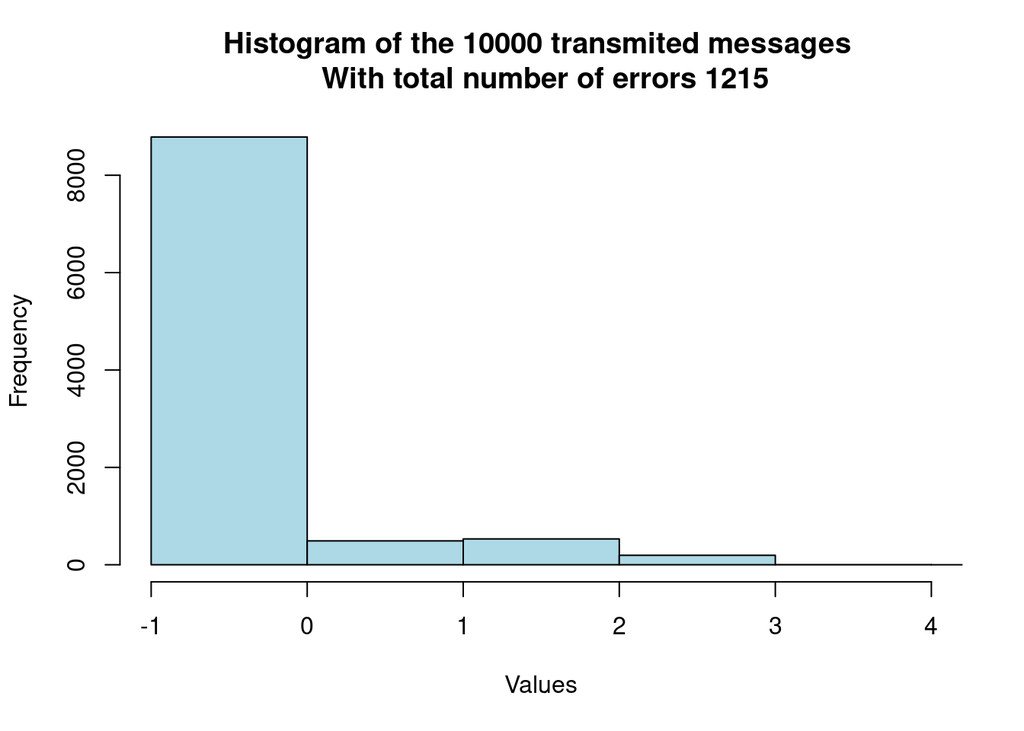

```r
N = 10000
h <- simulation(N)
lst = c()
for(i in 1:h[1]){
  lst = c(lst, 0)
}
for(i in 1:h[2]){
  lst = c(lst, 1)
}
for(i in 1:h[3]){
  lst = c(lst, 2)
}
for(i in 1:h[4]){
  lst = c(lst, 3)
}
for(i in 1:h[5]){
  lst = c(lst, 4)
}

#for(i in 1:length(h)){h[i] <- 4 - h[i]}
#print(h)
hist(lst,
     breaks = -1:5,
     main = paste("Histogram of the", round(10000), "transmited messages",'\n' , "With total number of errors", sum(h)-h[1]),
     col = "lightblue",
     xlab = "Values",
     xlim = c(-1,4)
     )
```

```r
dev = sd(lst)
num <- length(lst)
eps = dev*1.96/sqrt(num)
cat("Epsilon: ", eps)
```

```
## Epsilon:  0.01229046
```

## Task 1.2

By standart normal table:  
$\frac{ɛ\sqrt{N}}{σ} = 1.96$  
$\frac{ɛ\sqrt{N}}{0.6271269} = 1.96$  
$ɛ = \frac{1.229169}{\sqrt{N}}$